# R Notebook

# 1. Acquainting yourself with the data

As a first step, you want to find out some properties of the dataset with which you’ll be working. More specifically, you want to know more about the dataset’s number of observations and variables.

In this exercise, you’ll explore the iris dataset. If you want to learn more about it, you can click on it or type ?iris in the console.

Your job is to extract the number of observations and variables from iris. This dataset is readily available in R (in the datasets package that’s loaded by default).

```r
# iris is available from the datasets package
?iris
# Reveal number of observations and variables in two different ways
str(iris)
dim(iris)

# Show first and last observations in the iris data set
head(iris)
tail(iris)


# Summarize the iris data set
summary(iris)
```

[output not shown]

# 2. Classification: Filtering spam

Filtering spam from relevant emails is a typical machine learning task. Information such as word frequency, character frequency and the amount of capital letters can indicate whether an email is spam or not.

In the following exercise you’ll work with the dataset emails, which is loaded in your workspace (Source: UCI Machine Learning Repository). Here, several emails have been labeled by humans as spam (1) or not spam (0) and the results are found in the column spam. The considered feature in emails to predict whether it was spam or not is avg_capital_seq. It is the average amount of sequential capital letters found in each email.

In the code, you’ll find a crude spam filter we built for you, spam_classifier() that uses avg_capital_seq to predict whether an email is spam or not. In the function definition, it’s important to realize that x refers to avg_capital_seq. So where the avg_capital_seq is greater than 4, spam_classifier() predicts the email is spam (1), if avg_capital_seq is inclusively between 3 and 4, it predicts not spam (0), and so on. This classifier’s methodology of predicting whether an email is spam or not seems pretty random, but let’s see how it does anyways!

- Check the dimensions of this dataset. Use dim().
- Inspect the definition of spam_classifier(). It’s a simple set of statements that decide between spam and no spam based on a single input vector.
- Pass the avg_capital_seq column of emails to spam_classifier() to determine which emails are spam and which aren’t. Assign the resulting outcomes to spam_pred.
- Compare the vector with your predictions, spam_pred, to the true spam labels in emails$spam with the == operator. Simply print out the result. This can be done in one line of code! How many of the emails were correctly classified?

```r
# The emails dataset is already loaded into your workspace
emails = data.frame(avg_capital_seq = c(1.000, 2.112, 4.123, 1.863, 2.973, 1.687, 5.891, 3.167, 1.230, 2.441, 3.555, 3.250, 1.333), spam = c(0, 0, 1, 0, 1, 0, 1, 0, 0, 1, 0, 0, 1))

# Show the dimensions of emails
dim(emails)

# Inspect definition of spam_classifier()
spam_classifier <- function(x){
  prediction <- rep(NA, length(x)) # initialize prediction vector
  prediction[x > 4] <- 1
  prediction[x >= 3 & x <= 4] <- 0
  prediction[x >= 2.2 & x < 3] <- 1
  prediction[x >= 1.4 & x < 2.2] <- 0
  prediction[x > 1.25 & x < 1.4] <- 1
  prediction[x <= 1.25] <- 0
  return(prediction) # prediction is either 0 or 1
}

# Apply the classifier to the avg_capital_seq column: spam_pred
spam_pred = spam_classifier(emails$avg_capital_seq)

# Compare spam_pred to emails$spam. Use ==
spam_pred == emails$spam
```

[output not shown]

# 3. Regression: LinkedIn views for the next 3 days

It’s time for you to make another prediction with regression! More precisely, you’ll analyze the number of views of your LinkedIn profile. With your growing network and your data science skills improving daily, you wonder if you can predict how often your profile will be visited in the future based on the number of days it’s been since you created your LinkedIn account.

The instructions will help you predict the number of profile views for the next 3 days, based on the views for the past 3 weeks. The linkedin vector, which contains this information, is already available in your workspace.

- Create a vector days with the numbers from 1 to 21, which represent the previous 3 weeks of your linkedin views. You can use the seq() function, or simply :.
- Fit a linear model that explains the LinkedIn views. Use the lm() function such that linkedin ( number of views) is a function of days (number of days since you made your account). As an example, lm(y ~ x) builds a linear model such that y is a function of x, or more colloquially, y is based on x. Assign the resulting linear model to linkedin_lm.
- Using this linear model, predict the number of views for the next three days (days 22, 23 and 24). Use predict() and the predefined future_days data frame. Assign the result to linkedin_pred.
- See how the remaining code plots both the historical data and the predictions. Try to interpret the result.

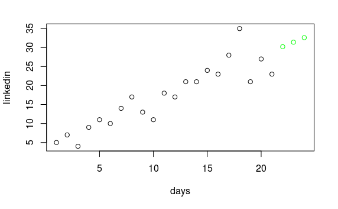

```r
# linkedin is already available in your workspace
linkedin = c(5,  7,  4,  9, 11, 10, 14, 17, 13, 11, 18, 17, 21, 21, 24, 23, 28, 35, 21, 27, 23)
# Create the days vector
days = seq(1, 21)
# Fit a linear model called on the linkedin views per day: linkedin_lm
linkedin_lm = lm(linkedin ~ days)
# Predict the number of views for the next three days: linkedin_pred
future_days <- data.frame(days = 22:24)
linkedin_pred <- predict(linkedin_lm, future_days)
# Plot historical data and predictions
plot(linkedin ~ days, xlim = c(1, 24))
points(22:24, linkedin_pred, col = "green")
```

# 4. Clustering: Separating the iris species

Last but not least, there’s clustering. This technique tries to group your objects. It does this without any prior knowledge of what these groups could or should look like. For clustering, the concepts of `prior knowledge` and `unseen observations` are less meaningful than for classification and regression.

In this exercise, you’ll group irises in 3 distinct clusters, based on several flower characteristics in the `iris` dataset. It has already been chopped up in a data frame `my_iris` and a vector `species`, as shown in the sample code on the right.

The clustering itself will be done with the *kmeans()* function. How the algorithm actually works, will be explained in the last chapter. For now, just try it out to gain some intuition!

Note: In problems that have a random aspect (like this problem with *kmeans())*, the *set.seed()* function will be used to enforce reproducibility. If you fix the seed, the random numbers that are generated (e.g. in *kmeans()*) are always the same.

- Use the *kmeans()* function. The first argument is `my_iris`; the second argument is 3, as you want to find three clusters `in my_iris`. Assign the result to a new variable, `kmeans_iris`.
- The actual species of the observations is stored in species. Use `table()` to compare it to the groups that the clustering came up with. These groups can be found in the cluster attribute of `kmeans_iris`.
- Inspect the code that generates a plot of Petal.Length against Petal.Width and colors by cluster.

```r
# Set random seed. Don't remove this line.
set.seed(1)
# Chop up iris in my_iris and species
my_iris <- iris[-5]
species <- iris$Species
# Perform k-means clustering on my_iris: kmeans_iris
kmeans_iris = kmeans(my_iris, 3)
# Compare the actual Species to the clustering using table()
table(species, kmeans_iris$cluster)
```

```
species       1  2  3
  setosa     50  0  0
  versicolor  0  2 48
  virginica   0 36 14
```

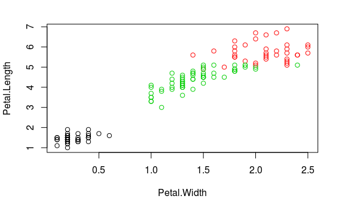

```r
# Plot Petal.Width against Petal.Length, coloring by cluster
plot(Petal.Length ~ Petal.Width, data = my_iris, col = kmeans_iris$cluster)
```

# 5. Getting practical with supervised learning

Previously, you used *kmeans()* to perform clustering on the *iris* dataset. Remember that you created your own copy of the dataset, and dropped the *Species* attribute? That’s right, you removed the labels of the observations.

- Take a look at the *iris* dataset, using *str()* and *summary()*.
- The code that builds a supervised learning model with the *rpart()* function from the `rpart` package is already provided for you. This model trains a decision tree on the *iris* dataset.
- Use the *predict()* function with the tree model as the first argument. The second argument should be a data frame containing observations of which you want to predict the label. In this case, you can use the predefined unseen data frame. The third argument should be *type = “class”*. Simply print out the result of this prediction step.

```r
library(rpart)
# Set random seed. Don't remove this line.
set.seed(1)
# Take a look at the iris dataset
str(iris)
```

```
'data.frame':   150 obs. of  5 variables:
 $ Sepal.Length: num  5.1 4.9 4.7 4.6 5 5.4 4.6 5 4.4 4.9 ...
 $ Sepal.Width : num  3.5 3 3.2 3.1 3.6 3.9 3.4 3.4 2.9 3.1 ...
 $ Petal.Length: num  1.4 1.4 1.3 1.5 1.4 1.7 1.4 1.5 1.4 1.5 ...
 $ Petal.Width : num  0.2 0.2 0.2 0.2 0.2 0.4 0.3 0.2 0.2 0.1 ...
 $ Species     : Factor w/ 3 levels "setosa","versicolor",..: 1 1 1 1 1 1 1 1 1 1 ...
```

```r
summary(iris)
```

```
  Sepal.Length    Sepal.Width     Petal.Length    Petal.Width          Species
 Min.   :4.300   Min.   :2.000   Min.   :1.000   Min.   :0.100   setosa    :50
 1st Qu.:5.100   1st Qu.:2.800   1st Qu.:1.600   1st Qu.:0.300   versicolor:50
 Median :5.800   Median :3.000   Median :4.350   Median :1.300   virginica :50
 Mean   :5.843   Mean   :3.057   Mean   :3.758   Mean   :1.199
 3rd Qu.:6.400   3rd Qu.:3.300   3rd Qu.:5.100   3rd Qu.:1.800
 Max.   :7.900   Max.   :4.400   Max.   :6.900   Max.   :2.500
```

```r
# A decision tree model has been built for you
tree <- rpart(Species ~ Sepal.Length + Sepal.Width + Petal.Length + Petal.Width,
              data = iris, method = "class")
# A dataframe containing unseen observations
unseen <- data.frame(Sepal.Length = c(5.3, 7.2),
                     Sepal.Width = c(2.9, 3.9),
                     Petal.Length = c(1.7, 5.4),
                     Petal.Width = c(0.8, 2.3))
# Predict the label of the unseen observations. Print out the result.
predict(tree, unseen, type = "class")
```

```
        1         2
   setosa virginica
Levels: setosa versicolor virginica
```

```r
?rpart
```

```
No documentation for ‘rpart’ in specified packages and libraries:
you could try ‘??rpart’
```

# 6. How to do unsupervised learning (1)

To cluster the different observations, you will once again use *kmeans()*.

In short, your job is to cluster the cars in 2 groups, but don’t forget to explore the dataset first!

- Explore the dataset using *str()* and *summary()*.
- Use *kmeans()* with two arguments to group the cars into two clusters based on the contents of the cars data frame. Assign the result to `km_cars`.
- Print out the cluster element of `km_cars`; it shows which cars belong to which clusters.

```r
# The cars data frame is pre-loaded
# Set random seed. Don't remove this line.
set.seed(1)
# Explore the cars dataset
str(cars)
```

```
'data.frame':   50 obs. of  2 variables:
 $ speed: num  4 4 7 7 8 9 10 10 10 11 ...
 $ dist : num  2 10 4 22 16 10 18 26 34 17 ...
```

```r
summary(cars)
```

```
     speed           dist
 Min.   : 4.0   Min.   :  2.00
 1st Qu.:12.0   1st Qu.: 26.00
 Median :15.0   Median : 36.00
 Mean   :15.4   Mean   : 42.98
 3rd Qu.:19.0   3rd Qu.: 56.00
 Max.   :25.0   Max.   :120.00
```

```r
# Group the dataset into two clusters: km_cars
km_cars = kmeans(cars, 2)
# Print out the contents of each cluster
km_cars$cluster
```

```
 [1] 1 1 1 1 1 1 1 1 1 1 1 1 1 1 1 1 1 1 1 1 1 2 2 1 1 2 1 1 1 1 2 1 2 2
[35] 2 1 1 2 1 1 2 2 2 2 2 2 2 2 2 2
```

# 7. How to do unsupervised learning (2)

An important part in machine learning is understanding your results. In the case of clustering, visualization is key to interpretation! One way to achieve this is by plotting the features of the cars and coloring the points based on their corresponding cluster.

In this exercise you’ll summarize your results in a comprehensive figure. The dataset cars is already available in your workspace; the code to perform the clustering is already available

- Finish the *plot()* command by coloring the cars based on their cluster. Do this by setting the col argument to the cluster partitioning vector: *km_cars$cluster*.
- Print out the clusters’ centroids, which are kind of like the centers of each cluster. They can be found in the centers element of *km_cars*.
- Replace the ___ in *points()* with the clusters’ centroids. This will add the centroids to your earlier plot. To learn about the other parameters that have been defined for you, have a look at the graphical parameters documentation.

```r
# The cars data frame is pre-loaded
# Set random seed. Don't remove this line
set.seed(1)
# Group the dataset into two clusters: km_cars
km_cars <- kmeans(cars, 2)
# Add code: color the points in the plot based on the clusters
plot(cars, col = km_cars$cluster)
# Print out the cluster centroids
km_cars$centers
```

```
     speed     dist
1 12.84375 27.15625
2 19.94444 71.11111
```

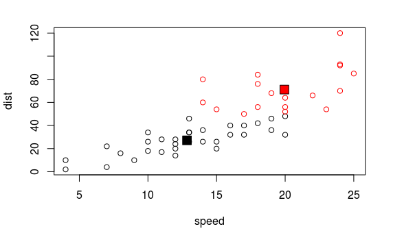

```r
# Replace the ___ part: add the centroids to the plot
points(km_cars$centers, pch = 22, bg = c(1, 2), cex = 2)
```